# 电商岗位招聘和薪酬水平

## 总述

本次采集有效数据3815条（城市发布量>=100），主要分析电子商务相关岗位，如电商运营、推广、客服、店铺管理员、电商总监或经理等，我们将从如下方面分析：

- 01.城市分布：深圳占28%，平均月薪11038元；广州占28%，平均月薪9571元；上海占15%，平均月薪12431元；其余城市均在6%或以下。
- 02.行业分布：互联网/电商占22%，平均月薪9990元；贸易/进出口占14%，平均月薪9999元；快消品占10%，平均月薪10843元。
- 03.公司规模：1000人以下占90%，平均月薪10035元；1000-5000人占7%，平均月薪11818元；5000人以上占3%，平均月薪13251元。
- 04.公司类型：民营占84%，平均月薪9924元；外企占7%，平均月薪12464元。
- 05.工作经验：5年以下占92%，平均月薪9474元；5-10年占7%，平均月薪19047元。
- 06.学历要求：大专占71%，平均月薪9855元；本科占18%，平均月薪13606元。
- 07.细分岗位：电商总监平均月薪23827元；电商经理平均月薪14163元；电商基层8997元。

## 01.城市分布

[figure not shown]

roadmap

## 02.行业分布

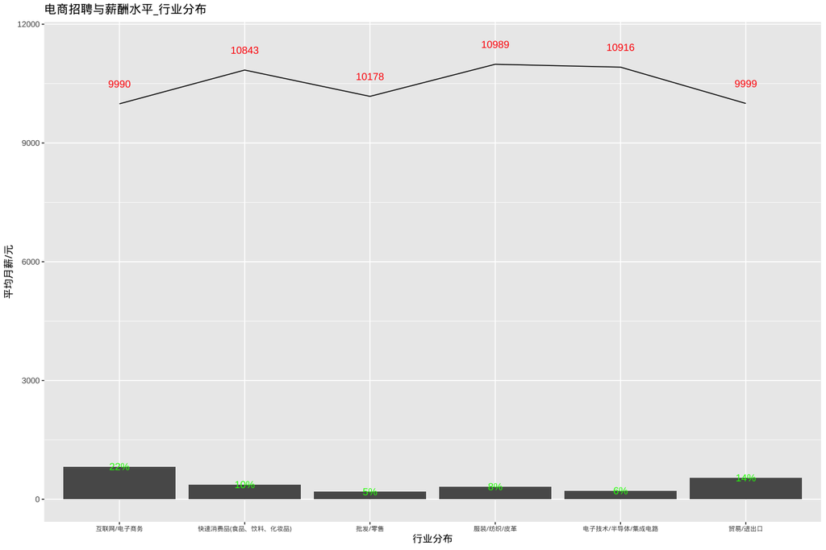

industries

## 03.公司规模

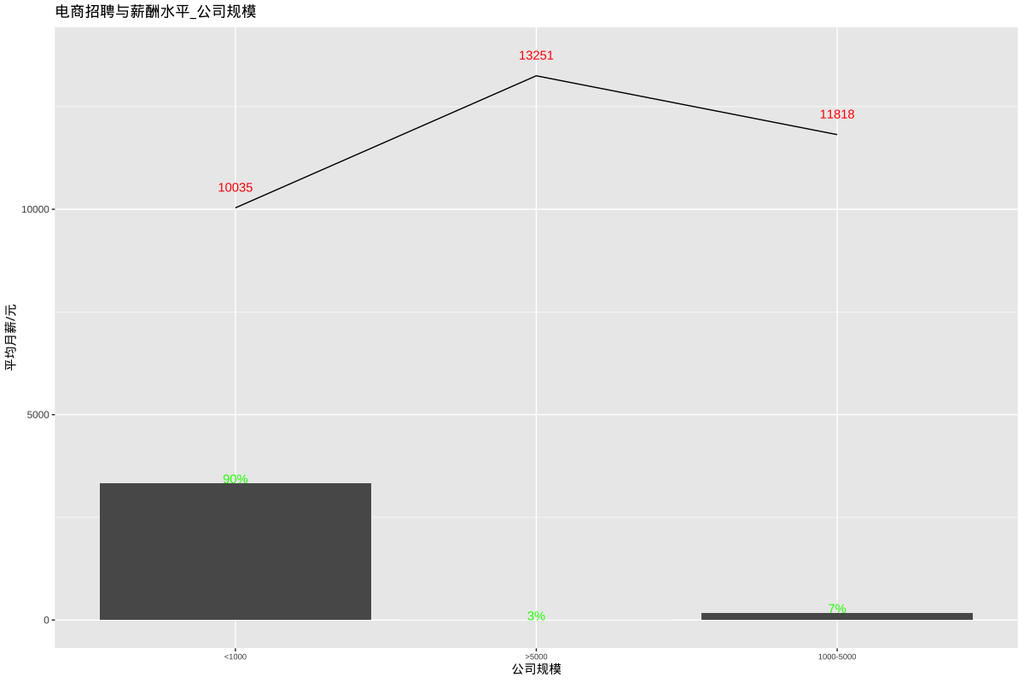

com_size

## 04.公司类型

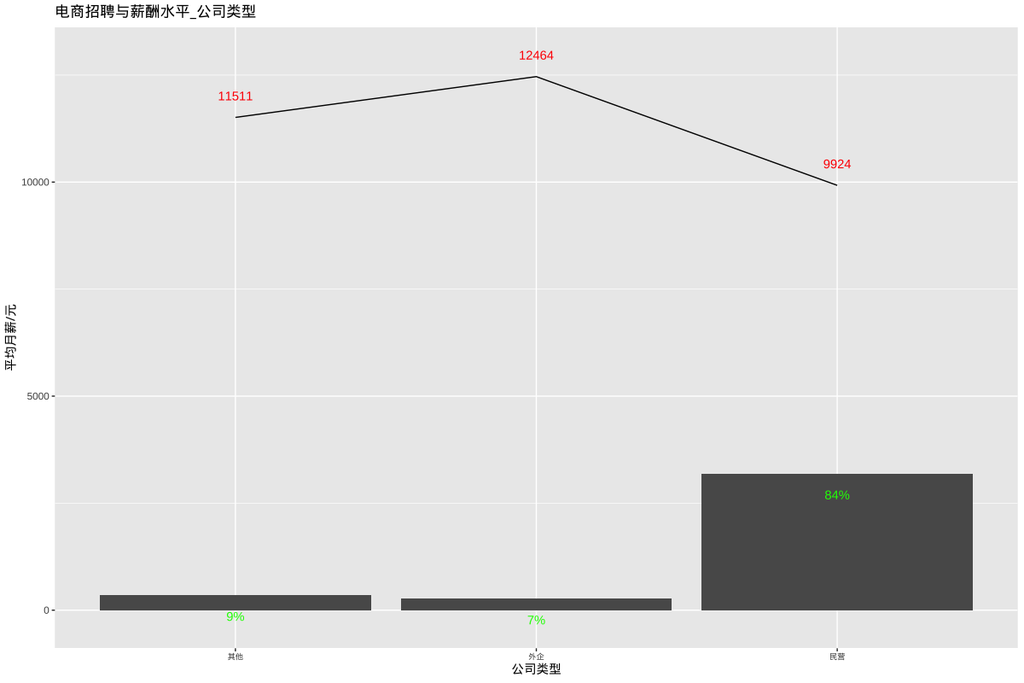

com_type

## 05.工作经验

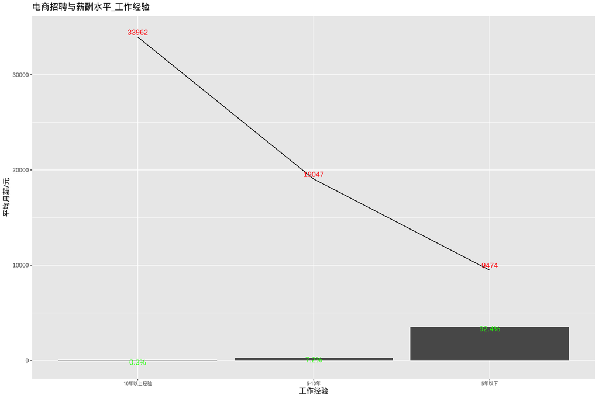

experience

## 06.学历要求

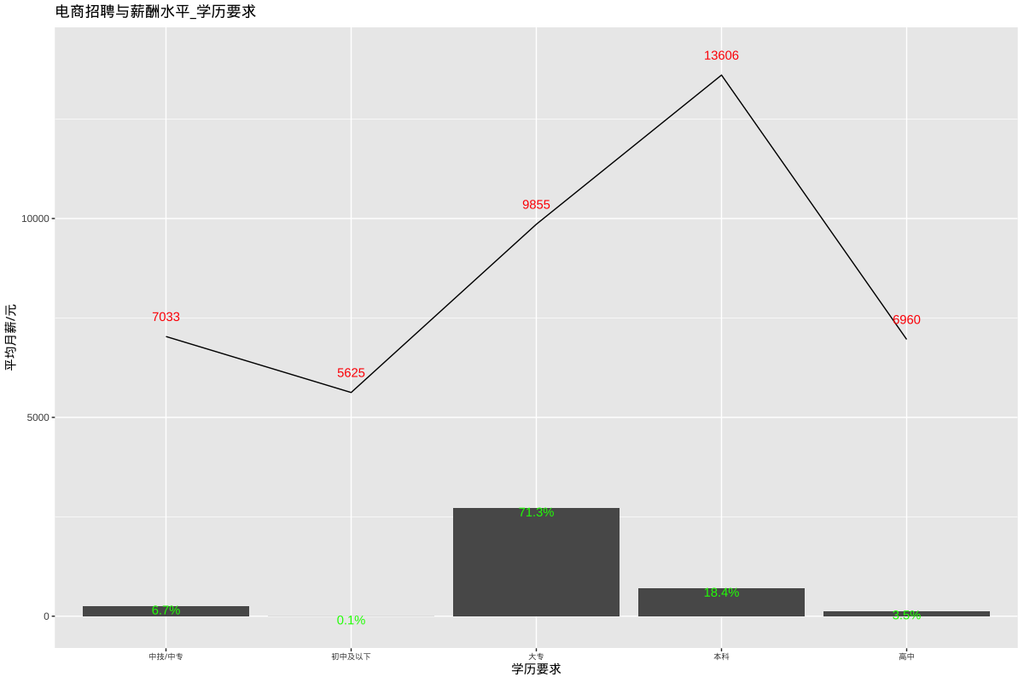

education

## 07.细分岗位

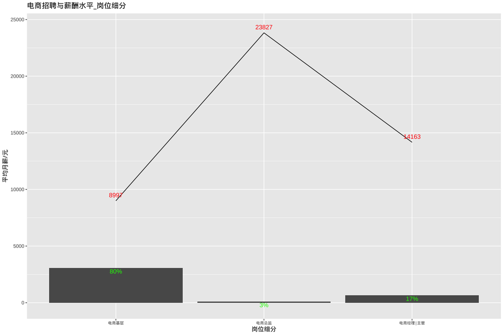

subclass